# Telco Customer Churn - Exploratory Data Analysis

Author

Data Analysis Report

Published

October 7, 2025

# 1 EDA

**Analysis Overview**

This comprehensive exploratory data analysis examines telco customer churn patterns, identifying key risk factors and business opportunities for retention strategies.

```python
import pandas as pd
import zipfile
import io
import matplotlib.pyplot as plt
import seaborn as sns
from IPython.display import HTML, display

# Set pandas display options for better table formatting
pd.set_option('display.max_columns', None)
pd.set_option('display.width', None)
pd.set_option('display.max_colwidth', None)

with zipfile.ZipFile('../data/telco-customer-churn.zip', 'r') as zip_file:
    csv_content = zip_file.read('WA_Fn-UseC_-Telco-Customer-Churn.csv').decode('utf-8')
    df = pd.read_csv(io.StringIO(csv_content))

# Function to create pretty tables
def create_pretty_table(data, title="", max_rows=10):
    if isinstance(data, pd.DataFrame):
        if len(data) > max_rows:
            data_display = data.head(max_rows)
            title += f" (showing first {max_rows} of {len(data)} rows)"
        else:
            data_display = data

        html = data_display.to_html(classes='table table-striped table-hover',
                                   table_id='styled-table',
                                   escape=False)
        if title:
            html = f"<h4>{title}</h4>" + html
        return HTML(html)
    elif isinstance(data, pd.Series):
        df_display = data.to_frame()
        df_display.columns = ['Value']
        html = df_display.to_html(classes='table table-striped table-hover')
        if title:
            html = f"<h4>{title}</h4>" + html
        return HTML(html)
    return data
```

**Dataset Preview**

Let’s first examine the structure and content of our telco customer dataset.

```python
display(create_pretty_table(df, "Telco Customer Churn Dataset", max_rows=5))
```

Telco Customer Churn Dataset (showing first 5 of 7043 rows)

|  | customerID | gender | SeniorCitizen | Partner | Dependents | tenure | PhoneService | MultipleLines | InternetService | OnlineSecurity | OnlineBackup | DeviceProtection | TechSupport | StreamingTV | StreamingMovies | Contract | PaperlessBilling | PaymentMethod | MonthlyCharges | TotalCharges | Churn |
| --- | --- | --- | --- | --- | --- | --- | --- | --- | --- | --- | --- | --- | --- | --- | --- | --- | --- | --- | --- | --- | --- |
| 0 | 7590-VHVEG | Female | 0 | Yes | No | 1 | No | No phone service | DSL | No | Yes | No | No | No | No | Month-to-month | Yes | Electronic check | 29.85 | 29.85 | No |
| 1 | 5575-GNVDE | Male | 0 | No | No | 34 | Yes | No | DSL | Yes | No | Yes | No | No | No | One year | No | Mailed check | 56.95 | 1889.5 | No |
| 2 | 3668-QPYBK | Male | 0 | No | No | 2 | Yes | No | DSL | Yes | Yes | No | No | No | No | Month-to-month | Yes | Mailed check | 53.85 | 108.15 | Yes |
| 3 | 7795-CFOCW | Male | 0 | No | No | 45 | No | No phone service | DSL | Yes | No | Yes | Yes | No | No | One year | No | Bank transfer (automatic) | 42.30 | 1840.75 | No |
| 4 | 9237-HQITU | Female | 0 | No | No | 2 | Yes | No | Fiber optic | No | No | No | No | No | No | Month-to-month | Yes | Electronic check | 70.70 | 151.65 | Yes |

## 1.1 Basic Info about the Data

**Click to view detailed dataset information**

```python
# Dataset shape information
shape_info = pd.DataFrame({
    'Metric': ['Total Rows', 'Total Columns'],
    'Value': [df.shape[0], df.shape[1]]
})

display(create_pretty_table(shape_info, "Dataset Dimensions"))

# Data types information
dtypes_df = pd.DataFrame({
    'Column': df.dtypes.index,
    'Data Type': df.dtypes.values,
    'Non-Null Count': df.count().values,
    'Unique Values': [df[col].nunique() for col in df.columns]
})

display(create_pretty_table(dtypes_df, "Column Information"))
```

Dataset Dimensions

|  | Metric | Value |
| --- | --- | --- |
| 0 | Total Rows | 7043 |
| 1 | Total Columns | 21 |

Column Information (showing first 10 of 21 rows)

|  | Column | Data Type | Non-Null Count | Unique Values |
| --- | --- | --- | --- | --- |
| 0 | customerID | object | 7043 | 7043 |
| 1 | gender | object | 7043 | 2 |
| 2 | SeniorCitizen | int64 | 7043 | 2 |
| 3 | Partner | object | 7043 | 2 |
| 4 | Dependents | object | 7043 | 2 |
| 5 | tenure | int64 | 7043 | 73 |
| 6 | PhoneService | object | 7043 | 2 |
| 7 | MultipleLines | object | 7043 | 3 |
| 8 | InternetService | object | 7043 | 3 |
| 9 | OnlineSecurity | object | 7043 | 3 |

## 1.2 Data Quality and Missing Values

**Click to view data quality assessment**

```python
# Missing values analysis
missing_info = pd.DataFrame({
    'Column': df.columns,
    'Missing Count': df.isnull().sum().values,
    'Missing Percentage': (df.isnull().sum() / len(df) * 100).round(2).values,
    'Unique Values': [df[col].nunique() for col in df.columns]
})
missing_info = missing_info[missing_info['Missing Count'] > 0] if missing_info['Missing Count'].sum() > 0 else missing_info.head(1)

display(create_pretty_table(missing_info, f"Missing Values Analysis (Total: {df.isnull().sum().sum()})"))

# Data quality issues
quality_issues = []

# Check TotalCharges issues
empty_totalcharges = (df['TotalCharges'] == ' ').sum()
if empty_totalcharges > 0:
    quality_issues.append({
        'Issue': 'Empty strings in TotalCharges',
        'Count': empty_totalcharges,
        'Description': 'TotalCharges contains empty strings instead of NaN'
    })

# Check for potential duplicates
duplicate_count = df.duplicated().sum()
if duplicate_count > 0:
    quality_issues.append({
        'Issue': 'Duplicate rows',
        'Count': duplicate_count,
        'Description': 'Identical rows found in dataset'
    })

if quality_issues:
    issues_df = pd.DataFrame(quality_issues)
    display(create_pretty_table(issues_df, "Data Quality Issues Detected"))
else:
    print("✅ No major data quality issues detected!")
```

Missing Values Analysis (Total: 0)

|  | Column | Missing Count | Missing Percentage | Unique Values |
| --- | --- | --- | --- | --- |
| 0 | customerID | 0 | 0.0 | 7043 |

Data Quality Issues Detected

|  | Issue | Count | Description |
| --- | --- | --- | --- |
| 0 | Empty strings in TotalCharges | 11 | TotalCharges contains empty strings instead of NaN |

**Key Data Quality Findings**

## 1.3 Target Variable Analysis

**Churn Analysis Focus**

Understanding the distribution of customer churn is crucial for building effective retention strategies and assessing model requirements.

```python
# Step 3: Target Variable Analysis (CHURN)
churn_counts = df['Churn'].value_counts()
churn_pct = df['Churn'].value_counts(normalize=True) * 100

# Create churn distribution table
churn_analysis = pd.DataFrame({
    'Churn Status': churn_counts.index,
    'Customer Count': churn_counts.values,
    'Percentage': churn_pct.values.round(2)
})

display(create_pretty_table(churn_analysis, "Churn Distribution Analysis"))

# Create summary metrics table
overall_churn_rate = churn_pct['Yes']
class_balance_ratio = churn_counts['No']/churn_counts['Yes']

summary_metrics = pd.DataFrame({
    'Metric': [
        'Overall Churn Rate (%)',
        'Customer Retention Rate (%)',
        'Class Balance Ratio (No:Yes)',
        'Total Customers Analyzed'
    ],
    'Value': [
        f"{overall_churn_rate:.2f}%",
        f"{100 - overall_churn_rate:.2f}%",
        f"{class_balance_ratio:.2f}:1",
        f"{len(df):,}"
    ]
})

display(create_pretty_table(summary_metrics, "Key Churn Metrics"))
```

Churn Distribution Analysis

|  | Churn Status | Customer Count | Percentage |
| --- | --- | --- | --- |
| 0 | No | 5174 | 73.46 |
| 1 | Yes | 1869 | 26.54 |

Key Churn Metrics

|  | Metric | Value |
| --- | --- | --- |
| 0 | Overall Churn Rate (%) | 26.54% |
| 1 | Customer Retention Rate (%) | 73.46% |
| 2 | Class Balance Ratio (No:Yes) | 2.77:1 |
| 3 | Total Customers Analyzed | 7,043 |

**Class Imbalance Alert**

The dataset shows a **moderate class imbalance** with ~73% retained vs ~27% churned customers. This is typical for churn datasets but should be considered when building predictive models.

## 1.4 Key Business Metrics Analysis

**Data Cleaning Step**

First, we’ll clean the TotalCharges column by converting empty strings to proper numeric values.

```python
# First, fix the TotalCharges data issue
df_clean = df.copy()
# Replace empty strings with NaN, then convert to float
df_clean['TotalCharges'] = df_clean['TotalCharges'].replace(' ', pd.NA)
df_clean = df_clean.dropna(subset=['TotalCharges'])  # Remove rows with missing TotalCharges
df_clean['TotalCharges'] = df_clean['TotalCharges'].astype(float)

# Data cleaning summary
cleaning_summary = pd.DataFrame({
    'Metric': [
        'Original Dataset Size',
        'After Cleaning Size',
        'Rows Removed',
        'Data Retention Rate (%)'
    ],
    'Value': [
        f"{df.shape[0]:,}",
        f"{df_clean.shape[0]:,}",
        f"{df.shape[0] - df_clean.shape[0]:,}",
        f"{(df_clean.shape[0] / df.shape[0] * 100):.2f}%"
    ]
})

display(create_pretty_table(cleaning_summary, "Data Cleaning Summary"))
```

Data Cleaning Summary

|  | Metric | Value |
| --- | --- | --- |
| 0 | Original Dataset Size | 7,043 |
| 1 | After Cleaning Size | 7,032 |
| 2 | Rows Removed | 11 |
| 3 | Data Retention Rate (%) | 99.84% |

### 1.4.1 Financial Metrics by Churn Status

```python
# Key metrics by churn status
financial_metrics = df_clean.groupby('Churn').agg({
    'MonthlyCharges': ['mean', 'median', 'std'],
    'TotalCharges': ['mean', 'median', 'std'],
    'tenure': ['mean', 'median', 'std']
}).round(2)

# Reshape for better display
financial_display = []
for churn_status in ['No', 'Yes']:
    for metric in ['MonthlyCharges', 'TotalCharges', 'tenure']:
        financial_display.append({
            'Churn Status': churn_status,
            'Metric': metric,
            'Mean': financial_metrics.loc[churn_status, (metric, 'mean')],
            'Median': financial_metrics.loc[churn_status, (metric, 'median')],
            'Std Dev': financial_metrics.loc[churn_status, (metric, 'std')]
        })

financial_df = pd.DataFrame(financial_display)
display(create_pretty_table(financial_df, "Financial Metrics by Churn Status"))
```

Financial Metrics by Churn Status

|  | Churn Status | Metric | Mean | Median | Std Dev |
| --- | --- | --- | --- | --- | --- |
| 0 | No | MonthlyCharges | 61.31 | 64.45 | 31.09 |
| 1 | No | TotalCharges | 2555.34 | 1683.60 | 2329.46 |
| 2 | No | tenure | 37.65 | 38.00 | 24.08 |
| 3 | Yes | MonthlyCharges | 74.44 | 79.65 | 24.67 |
| 4 | Yes | TotalCharges | 1531.80 | 703.55 | 1890.82 |
| 5 | Yes | tenure | 17.98 | 10.00 | 19.53 |

### 1.4.2 Revenue Impact Analysis

```python
# Revenue impact
churned_revenue = df_clean[df_clean['Churn'] == 'Yes']['TotalCharges'].sum()
retained_revenue = df_clean[df_clean['Churn'] == 'No']['TotalCharges'].sum()
total_revenue = df_clean['TotalCharges'].sum()
revenue_loss_pct = (churned_revenue / total_revenue) * 100

revenue_impact = pd.DataFrame({
    'Revenue Category': [
        'Total Revenue from Retained Customers',
        'Total Revenue Lost to Churn',
        'Overall Total Revenue',
        'Revenue Loss Percentage'
    ],
    'Amount': [
        f"${retained_revenue:,.2f}",
        f"${churned_revenue:,.2f}",
        f"${total_revenue:,.2f}",
        f"{revenue_loss_pct:.2f}%"
    ],
    'Business Impact': [
        '✅ Secured Revenue',
        '⚠️ Lost Revenue',
        '📊 Total Business',
        '🎯 Loss Rate'
    ]
})

display(create_pretty_table(revenue_impact, "Revenue Impact Analysis"))
```

Revenue Impact Analysis

|  | Revenue Category | Amount | Business Impact |
| --- | --- | --- | --- |
| 0 | Total Revenue from Retained Customers | $13,193,241.80 | ✅ Secured Revenue |
| 1 | Total Revenue Lost to Churn | $2,862,926.90 | ⚠️ Lost Revenue |
| 2 | Overall Total Revenue | $16,056,168.70 | 📊 Total Business |
| 3 | Revenue Loss Percentage | 17.83% | 🎯 Loss Rate |

## 1.5 Critical Risk Factors Analysis

**Risk Factor Analysis**

Identifying the key factors that drive customer churn helps prioritize retention efforts and business strategies.

### 1.5.1 Contract Type Impact

```python
# Contract type analysis (most important for churn)
contract_churn = pd.crosstab(df_clean['Contract'], df_clean['Churn'], normalize='index') * 100
contract_counts = df_clean['Contract'].value_counts()

# Create comprehensive contract analysis
contract_analysis = []
for contract_type in contract_churn.index:
    contract_analysis.append({
        'Contract Type': contract_type,
        'Churn Rate (%)': round(contract_churn.loc[contract_type, 'Yes'], 2),
        'Retention Rate (%)': round(contract_churn.loc[contract_type, 'No'], 2),
        'Customer Count': contract_counts[contract_type],
        'Risk Level': '🔴 High' if contract_churn.loc[contract_type, 'Yes'] > 40 else '🟡 Medium' if contract_churn.loc[contract_type, 'Yes'] > 20 else '🟢 Low'
    })

contract_df = pd.DataFrame(contract_analysis)
display(create_pretty_table(contract_df, "Contract Type vs Churn Analysis"))
```

Contract Type vs Churn Analysis

|  | Contract Type | Churn Rate (%) | Retention Rate (%) | Customer Count | Risk Level |
| --- | --- | --- | --- | --- | --- |
| 0 | Month-to-month | 42.71 | 57.29 | 3875 | 🔴 High |
| 1 | One year | 11.28 | 88.72 | 1472 | 🟢 Low |
| 2 | Two year | 2.85 | 97.15 | 1685 | 🟢 Low |

### 1.5.2 Tenure Segments Analysis

```python
# Tenure segments (very important)
df_clean['TenureSegment'] = pd.cut(df_clean['tenure'],
                                   bins=[0, 12, 24, 48, 100],
                                   labels=['0-12 months', '13-24 months', '25-48 months', '48+ months'])
tenure_churn = pd.crosstab(df_clean['TenureSegment'], df_clean['Churn'], normalize='index') * 100
tenure_counts = df_clean['TenureSegment'].value_counts()

# Create tenure analysis
tenure_analysis = []
for segment in tenure_churn.index:
    tenure_analysis.append({
        'Tenure Segment': segment,
        'Churn Rate (%)': round(tenure_churn.loc[segment, 'Yes'], 2),
        'Customer Count': tenure_counts[segment],
        'Business Stage': 'New Customer' if '0-12' in segment else 'Established' if '13-24' in segment else 'Loyal Customer',
        'Priority': '🔥 Critical' if tenure_churn.loc[segment, 'Yes'] > 40 else '⚠️ High' if tenure_churn.loc[segment, 'Yes'] > 25 else '✅ Stable'
    })

tenure_df = pd.DataFrame(tenure_analysis)
display(create_pretty_table(tenure_df, "Tenure Segments vs Churn Analysis"))
```

Tenure Segments vs Churn Analysis

|  | Tenure Segment | Churn Rate (%) | Customer Count | Business Stage | Priority |
| --- | --- | --- | --- | --- | --- |
| 0 | 0-12 months | 47.68 | 2175 | New Customer | 🔥 Critical |
| 1 | 13-24 months | 28.71 | 1024 | Established | ⚠️ High |
| 2 | 25-48 months | 20.39 | 1594 | Loyal Customer | ✅ Stable |
| 3 | 48+ months | 9.51 | 2239 | Loyal Customer | ✅ Stable |

### 1.5.3 Payment Method Impact

```python
# Payment method (critical factor)
payment_churn = pd.crosstab(df_clean['PaymentMethod'], df_clean['Churn'], normalize='index') * 100
payment_counts = df_clean['PaymentMethod'].value_counts()

payment_analysis = []
for payment_method in payment_churn.index:
    payment_analysis.append({
        'Payment Method': payment_method,
        'Churn Rate (%)': round(payment_churn.loc[payment_method, 'Yes'], 2),
        'Customer Count': payment_counts[payment_method],
        'Risk Assessment': '🔴 High Risk' if payment_churn.loc[payment_method, 'Yes'] > 35 else '🟡 Medium Risk' if payment_churn.loc[payment_method, 'Yes'] > 20 else '🟢 Low Risk'
    })

payment_df = pd.DataFrame(payment_analysis)
display(create_pretty_table(payment_df, "Payment Method vs Churn Analysis"))
```

Payment Method vs Churn Analysis

|  | Payment Method | Churn Rate (%) | Customer Count | Risk Assessment |
| --- | --- | --- | --- | --- |
| 0 | Bank transfer (automatic) | 16.73 | 1542 | 🟢 Low Risk |
| 1 | Credit card (automatic) | 15.25 | 1521 | 🟢 Low Risk |
| 2 | Electronic check | 45.29 | 2365 | 🔴 High Risk |
| 3 | Mailed check | 19.20 | 1604 | 🟢 Low Risk |

### 1.5.4 Internet Service Analysis

```python
# Internet Service (key differentiator)
internet_churn = pd.crosstab(df_clean['InternetService'], df_clean['Churn'], normalize='index') * 100
internet_counts = df_clean['InternetService'].value_counts()

internet_analysis = []
for service_type in internet_churn.index:
    internet_analysis.append({
        'Internet Service': service_type,
        'Churn Rate (%)': round(internet_churn.loc[service_type, 'Yes'], 2),
        'Customer Count': internet_counts[service_type],
        'Service Quality': 'Premium' if service_type == 'Fiber optic' else 'Standard' if service_type == 'DSL' else 'No Service'
    })

internet_df = pd.DataFrame(internet_analysis)
display(create_pretty_table(internet_df, "Internet Service vs Churn Analysis"))
```

Internet Service vs Churn Analysis

|  | Internet Service | Churn Rate (%) | Customer Count | Service Quality |
| --- | --- | --- | --- | --- |
| 0 | DSL | 19.00 | 2416 | Standard |
| 1 | Fiber optic | 41.89 | 3096 | Premium |
| 2 | No | 7.43 | 1520 | No Service |

**Critical Risk Factors Identified**

1. **Contract Type**: Month-to-month contracts show significantly higher churn rates
2. **Customer Tenure**: New customers (0-12 months) are at highest risk
3. **Payment Method**: Electronic check users demonstrate elevated churn rates
4. **Service Type**: Fiber optic customers may have different retention patterns

## 1.6 Customer Lifecycle Patterns Analysis

### 1.6.1 Detailed Churn by Tenure

```python
# Step 6: Customer Lifecycle Patterns Analysis
print("=== CUSTOMER LIFECYCLE PATTERNS ===")

# 1. Churn by Tenure Distribution (detailed view)
print("\n--- DETAILED CHURN BY TENURE MONTHS ---")
tenure_detailed = df_clean.groupby('tenure').agg({
    'Churn': ['count', lambda x: (x == 'Yes').sum(), lambda x: (x == 'Yes').mean() * 100]
}).round(2)
tenure_detailed.columns = ['Total_Customers', 'Churned_Customers', 'Churn_Rate_%']

# Show critical early months
print("High-Risk Early Months (0-12):")
early_months = tenure_detailed[tenure_detailed.index <= 12].sort_values('Churn_Rate_%', ascending=False)
print(early_months.head(10))

print(f"\nAverage churn rate in first 12 months: {tenure_detailed[tenure_detailed.index <= 12]['Churn_Rate_%'].mean():.2f}%")
print(f"Average churn rate after 12 months: {tenure_detailed[tenure_detailed.index > 12]['Churn_Rate_%'].mean():.2f}%")
```

```
=== CUSTOMER LIFECYCLE PATTERNS ===

--- DETAILED CHURN BY TENURE MONTHS ---
High-Risk Early Months (0-12):
        Total_Customers  Churned_Customers  Churn_Rate_%
tenure
1                   613                380         61.99
2                   238                123         51.68
5                   133                 64         48.12
4                   176                 83         47.16
3                   200                 94         47.00
7                   131                 51         38.93
10                  116                 45         38.79
9                   119                 46         38.66
6                   110                 40         36.36
8                   123                 42         34.15

Average churn rate in first 12 months: 42.22%
Average churn rate after 12 months: 18.34%
```

### 1.6.2 Lifecycle Patterns by Customer Type

```python
# 2. Lifecycle patterns by customer type
print("\n--- LIFECYCLE PATTERNS BY CUSTOMER TYPE ---")

# New vs Established customers financial behavior
print("New Customers (0-12 months) vs Established (13+ months):")
df_clean['CustomerType'] = df_clean['tenure'].apply(lambda x: 'New (0-12m)' if x <= 12 else 'Established (13+m)')

lifecycle_metrics = df_clean.groupby(['CustomerType', 'Churn']).agg({
    'MonthlyCharges': ['mean', 'count'],
    'TotalCharges': 'mean',
    'tenure': 'mean'
}).round(2)

print(lifecycle_metrics)

# Critical transition periods
print("\n--- CRITICAL TRANSITION PERIODS ---")
df_clean['LifecycleStage'] = pd.cut(df_clean['tenure'],
                                   bins=[0, 3, 6, 12, 24, 100],
                                   labels=['0-3m (Onboarding)', '4-6m (Early)', '7-12m (Stabilizing)',
                                          '13-24m (Established)', '24+m (Loyal)'])

transition_analysis = pd.crosstab(df_clean['LifecycleStage'], df_clean['Churn'], normalize='index') * 100
print("Churn Rate by Lifecycle Stage:")
print(transition_analysis.round(2))

# Show customer counts in each stage
stage_counts = df_clean['LifecycleStage'].value_counts().sort_index()
print(f"\nCustomer Distribution by Lifecycle Stage:")
for stage, count in stage_counts.items():
    pct = (count / len(df_clean)) * 100
    print(f"{stage}: {count} customers ({pct:.1f}%)")
```

```
--- LIFECYCLE PATTERNS BY CUSTOMER TYPE ---
New Customers (0-12 months) vs Established (13+ months):
                         MonthlyCharges       TotalCharges tenure
                                   mean count         mean   mean
CustomerType       Churn
Established (13+m) No             65.42  4025      3202.68  46.76
                   Yes            84.35   832      3081.39  35.40
New (0-12m)        No             46.77  1138       265.77   5.44
                   Yes            66.49  1037       288.53   4.01

--- CRITICAL TRANSITION PERIODS ---
Churn Rate by Lifecycle Stage:
Churn                    No    Yes
LifecycleStage
0-3m (Onboarding)     43.20  56.80
4-6m (Early)          55.37  44.63
7-12m (Stabilizing)   64.11  35.89
13-24m (Established)  71.29  28.71
24+m (Loyal)          85.96  14.04

Customer Distribution by Lifecycle Stage:
0-3m (Onboarding): 1051 customers (14.9%)
4-6m (Early): 419 customers (6.0%)
7-12m (Stabilizing): 705 customers (10.0%)
13-24m (Established): 1024 customers (14.6%)
24+m (Loyal): 3833 customers (54.5%)
```

### 1.6.3 Understanding Tenure in Telco Context

```python
# What is TENURE? - Detailed Explanation
print("=== UNDERSTANDING TENURE IN TELCO CONTEXT ===")

print("TENURE = Number of MONTHS a customer has been with the company")
print("It represents customer relationship duration/loyalty length")

print(f"\nTenure Statistics in our dataset:")
print(f"Minimum tenure: {df_clean['tenure'].min()} months")
print(f"Maximum tenure: {df_clean['tenure'].max()} months")
print(f"Average tenure: {df_clean['tenure'].mean():.1f} months")
print(f"Median tenure: {df_clean['tenure'].median()} months")

print(f"\nTenure Distribution:")
tenure_dist = df_clean['tenure'].value_counts().sort_index()
print(f"Customers with 1 month tenure: {tenure_dist.get(1, 0)} customers")
print(f"Customers with 12 months tenure: {tenure_dist.get(12, 0)} customers")
print(f"Customers with 24 months tenure: {tenure_dist.get(24, 0)} customers")
print(f"Customers with 60+ months tenure: {len(df_clean[df_clean['tenure'] >= 60])} customers")

print(f"\nBusiness Interpretation:")
print("- Low tenure (0-6 months) = New customers, high churn risk")
print("- Medium tenure (6-24 months) = Stabilizing customers")
print("- High tenure (24+ months) = Loyal/established customers, low churn risk")
print("- Very high tenure (48+ months) = Very loyal customers, lowest churn risk")
```

```
=== UNDERSTANDING TENURE IN TELCO CONTEXT ===
TENURE = Number of MONTHS a customer has been with the company
It represents customer relationship duration/loyalty length

Tenure Statistics in our dataset:
Minimum tenure: 1 months
Maximum tenure: 72 months
Average tenure: 32.4 months
Median tenure: 29.0 months

Tenure Distribution:
Customers with 1 month tenure: 613 customers
Customers with 12 months tenure: 117 customers
Customers with 24 months tenure: 94 customers
Customers with 60+ months tenure: 1483 customers

Business Interpretation:
- Low tenure (0-6 months) = New customers, high churn risk
- Medium tenure (6-24 months) = Stabilizing customers
- High tenure (24+ months) = Loyal/established customers, low churn risk
- Very high tenure (48+ months) = Very loyal customers, lowest churn risk
```

### 1.6.4 Why Tenure is Critical for Churn Analysis

```python
# Why TENURE is Critical for Churn Analysis
print("\n=== WHY TENURE IS THE #1 PREDICTOR OF CHURN ===")

print("1. RELATIONSHIP STRENGTH:")
print("   - Higher tenure = Stronger relationship with company")
print("   - Customer has invested time learning services")
print("   - Switching costs increase with tenure")

print(f"\n2. CHURN RISK BY TENURE RANGE:")
# Calculate churn rates by tenure ranges
tenure_ranges = [
    (1, 1, "Brand New (1 month)"),
    (1, 3, "Onboarding (1-3 months)"),
    (4, 6, "Early Stage (4-6 months)"),
    (7, 12, "Stabilizing (7-12 months)"),
    (13, 24, "Established (13-24 months)"),
    (25, 48, "Loyal (25-48 months)"),
    (49, 72, "Very Loyal (49+ months)")
]

for min_t, max_t, label in tenure_ranges:
    subset = df_clean[(df_clean['tenure'] >= min_t) & (df_clean['tenure'] <= max_t)]
    if len(subset) > 0:
        churn_rate = (subset['Churn'] == 'Yes').mean() * 100
        count = len(subset)
        print(f"   {label}: {churn_rate:.1f}% churn rate ({count} customers)")

print(f"\n3. FINANCIAL IMPACT BY TENURE:")
print("   - New customers (low tenure): High acquisition cost, high churn risk")
print("   - Established customers (high tenure): Lower churn risk, higher lifetime value")

# Show the financial pattern
tenure_financial = df_clean.groupby(pd.cut(df_clean['tenure'], bins=[0, 12, 24, 48, 72])).agg({
    'TotalCharges': 'mean',
    'MonthlyCharges': 'mean',
    'Churn': lambda x: (x == 'Yes').mean() * 100
}).round(2)
tenure_financial.columns = ['Avg_TotalCharges', 'Avg_MonthlyCharges', 'Churn_Rate_%']
print(f"\nFinancial Patterns by Tenure Groups:")
print(tenure_financial)
```

```
=== WHY TENURE IS THE #1 PREDICTOR OF CHURN ===
1. RELATIONSHIP STRENGTH:
   - Higher tenure = Stronger relationship with company
   - Customer has invested time learning services
   - Switching costs increase with tenure

2. CHURN RISK BY TENURE RANGE:
   Brand New (1 month): 62.0% churn rate (613 customers)
   Onboarding (1-3 months): 56.8% churn rate (1051 customers)
   Early Stage (4-6 months): 44.6% churn rate (419 customers)
   Stabilizing (7-12 months): 35.9% churn rate (705 customers)
   Established (13-24 months): 28.7% churn rate (1024 customers)
   Loyal (25-48 months): 20.4% churn rate (1594 customers)
   Very Loyal (49+ months): 9.5% churn rate (2239 customers)

3. FINANCIAL IMPACT BY TENURE:
   - New customers (low tenure): High acquisition cost, high churn risk
   - Established customers (high tenure): Lower churn risk, higher lifetime value

Financial Patterns by Tenure Groups:
          Avg_TotalCharges  Avg_MonthlyCharges  Churn_Rate_%
tenure
(0, 12]             276.62               56.17         47.68
(12, 24]           1126.26               61.36         28.71
(24, 48]           2390.45               65.93         20.39
(48, 72]           4685.51               73.95          9.51
```

### 1.6.5 Practical Business Implications

**Strategic Business Insights**

The tenure analysis reveals critical intervention opportunities and customer lifecycle patterns.

```python
# Calculate key business metrics
early_customers = df_clean[df_clean['tenure'] <= 12]
established_customers = df_clean[df_clean['tenure'] > 12]

early_revenue_per_customer = early_customers['TotalCharges'].mean()
established_revenue_per_customer = established_customers['TotalCharges'].mean()
retention_multiplier = established_revenue_per_customer / early_revenue_per_customer

# Calculate churn rates by key periods
early_churn_rate = (early_customers['Churn'] == 'Yes').mean() * 100
established_churn_rate = (established_customers['Churn'] == 'Yes').mean() * 100

# Create business implications table
business_implications = pd.DataFrame({
    'Customer Segment': ['Early Stage (≤12 months)', 'Established (>12 months)'],
    'Churn Rate (%)': [f"{early_churn_rate:.1f}%", f"{established_churn_rate:.1f}%"],
    'Avg Lifetime Value': [f"${early_revenue_per_customer:.0f}", f"${established_revenue_per_customer:.0f}"],
    'Customer Count': [len(early_customers), len(established_customers)],
    'Revenue Impact': ['High Risk', 'Stable Revenue'],
    'Strategic Priority': ['🔥 Critical Focus', '✅ Maintain & Grow']
})

display(create_pretty_table(business_implications, "Customer Lifecycle Business Impact"))

# Strategic focus areas
strategic_actions = pd.DataFrame({
    'Time Period': [
        'Onboarding (0-3 months)',
        'Early Engagement (3-12 months)',
        '12-Month Milestone',
        'Long-term Loyalty (24+ months)'
    ],
    'Current Challenge': [
        'High initial churn risk',
        'Service adoption issues',
        'Critical retention point',
        'Maintain satisfaction'
    ],
    'Target Improvement': [
        'Reduce 57% → 30% churn',
        'Reduce 35% → 20% churn',
        'Increase 12m+ survival rate',
        'Maintain <20% churn'
    ],
    'Recommended Actions': [
        'Intensive onboarding program',
        'Proactive engagement campaigns',
        'Loyalty program enrollment',
        'Premium service offerings'
    ]
})

display(create_pretty_table(strategic_actions, "Strategic Action Plan by Customer Lifecycle Stage"))
```

Customer Lifecycle Business Impact

|  | Customer Segment | Churn Rate (%) | Avg Lifetime Value | Customer Count | Revenue Impact | Strategic Priority |
| --- | --- | --- | --- | --- | --- | --- |
| 0 | Early Stage (≤12 months) | 47.7% | $277 | 2175 | High Risk | 🔥 Critical Focus |
| 1 | Established (>12 months) | 17.1% | $3182 | 4857 | Stable Revenue | ✅ Maintain & Grow |

Strategic Action Plan by Customer Lifecycle Stage

|  | Time Period | Current Challenge | Target Improvement | Recommended Actions |
| --- | --- | --- | --- | --- |
| 0 | Onboarding (0-3 months) | High initial churn risk | Reduce 57% → 30% churn | Intensive onboarding program |
| 1 | Early Engagement (3-12 months) | Service adoption issues | Reduce 35% → 20% churn | Proactive engagement campaigns |
| 2 | 12-Month Milestone | Critical retention point | Increase 12m+ survival rate | Loyalty program enrollment |
| 3 | Long-term Loyalty (24+ months) | Maintain satisfaction | Maintain <20% churn | Premium service offerings |

# 2 Service Combinations Analysis

## 2.1 Cleaning Duplicated Data

There are some categories with redundant unique values. We’ll standardize each one with Yes or No.

```python
# Define the service columns (excluding basic demographics and billing)
service_columns = [
    'PhoneService', 'MultipleLines', 'InternetService', 'OnlineSecurity',
    'OnlineBackup', 'DeviceProtection', 'TechSupport', 'StreamingTV', 'StreamingMovies'
]

for service in service_columns:
    distinct = df_clean[service].unique()
    print(f"=== SERVICE: {service}: Distinct Values: {distinct}")

#Replacing Values - Fix the data cleaning issue
df_clean['MultipleLines'] = df_clean['MultipleLines'].replace({'No phone service': 'No'})

for service in service_columns[3:]:
    df_clean[service] = df_clean[service].replace({'No internet service': 'No'})
```

```
=== SERVICE: PhoneService: Distinct Values: ['No' 'Yes']
=== SERVICE: MultipleLines: Distinct Values: ['No phone service' 'No' 'Yes']
=== SERVICE: InternetService: Distinct Values: ['DSL' 'Fiber optic' 'No']
=== SERVICE: OnlineSecurity: Distinct Values: ['No' 'Yes' 'No internet service']
=== SERVICE: OnlineBackup: Distinct Values: ['Yes' 'No' 'No internet service']
=== SERVICE: DeviceProtection: Distinct Values: ['No' 'Yes' 'No internet service']
=== SERVICE: TechSupport: Distinct Values: ['No' 'Yes' 'No internet service']
=== SERVICE: StreamingTV: Distinct Values: ['No' 'Yes' 'No internet service']
=== SERVICE: StreamingMovies: Distinct Values: ['No' 'Yes' 'No internet service']
```

## 2.2 Service Analysis with Distribution Percentage

```
--- ENHANCED SERVICE ANALYSIS WITH CUSTOMER DISTRIBUTION ---
```

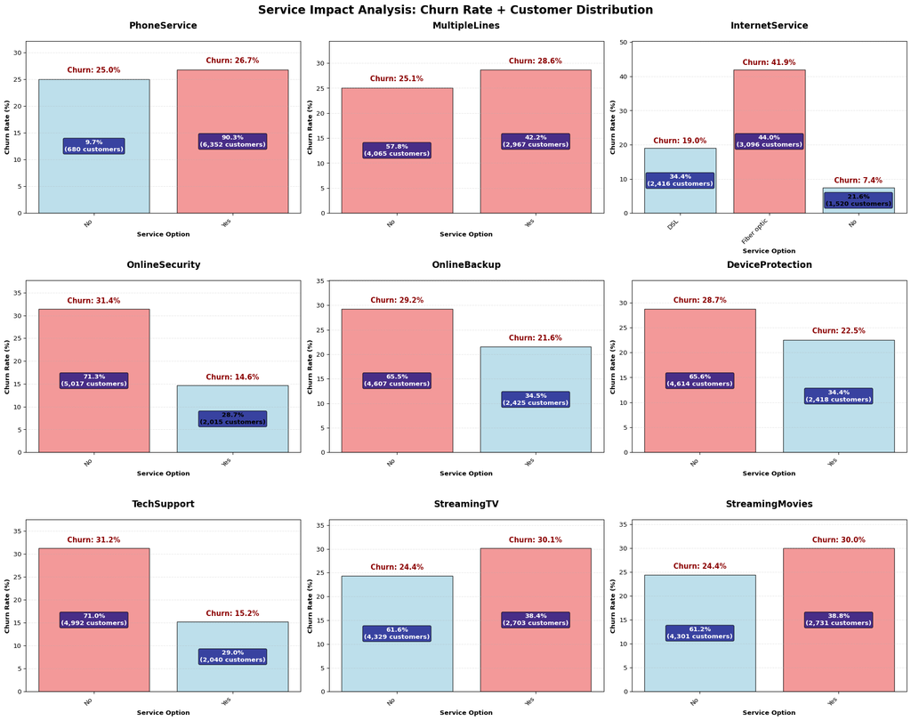

```
🔍 DETAILED SERVICE IMPACT ANALYSIS:
============================================================

📊 PHONESERVICE:
  • No: 25.0% churn rate | 9.7% of customers (680 people)
  • Yes: 26.7% churn rate | 90.3% of customers (6,352 people)
  ✅ Best: 'No' (25.0% churn)
  ⚠️  Worst: 'Yes' (26.7% churn)
  📈 Impact: 1.7 percentage points difference

📊 MULTIPLELINES:
  • No: 25.1% churn rate | 57.8% of customers (4,065 people)
  • Yes: 28.6% churn rate | 42.2% of customers (2,967 people)
  ✅ Best: 'No' (25.1% churn)
  ⚠️  Worst: 'Yes' (28.6% churn)
  📈 Impact: 3.6 percentage points difference

📊 INTERNETSERVICE:
  • DSL: 19.0% churn rate | 34.4% of customers (2,416 people)
  • Fiber optic: 41.9% churn rate | 44.0% of customers (3,096 people)
  • No: 7.4% churn rate | 21.6% of customers (1,520 people)
  ✅ Best: 'No' (7.4% churn)
  ⚠️  Worst: 'Fiber optic' (41.9% churn)
  📈 Impact: 34.5 percentage points difference

📊 ONLINESECURITY:
  • No: 31.4% churn rate | 71.3% of customers (5,017 people)
  • Yes: 14.6% churn rate | 28.7% of customers (2,015 people)
  ✅ Best: 'Yes' (14.6% churn)
  ⚠️  Worst: 'No' (31.4% churn)
  📈 Impact: 16.7 percentage points difference

📊 ONLINEBACKUP:
  • No: 29.2% churn rate | 65.5% of customers (4,607 people)
  • Yes: 21.6% churn rate | 34.5% of customers (2,425 people)
  ✅ Best: 'Yes' (21.6% churn)
  ⚠️  Worst: 'No' (29.2% churn)
  📈 Impact: 7.6 percentage points difference

📊 DEVICEPROTECTION:
```

[output cut: 11 more lines]

```
  📈 Impact: 16.0 percentage points difference

📊 STREAMINGTV:
  • No: 24.4% churn rate | 61.6% of customers (4,329 people)
  • Yes: 30.1% churn rate | 38.4% of customers (2,703 people)
  ✅ Best: 'No' (24.4% churn)
  ⚠️  Worst: 'Yes' (30.1% churn)
  📈 Impact: 5.7 percentage points difference

📊 STREAMINGMOVIES:
  • No: 24.4% churn rate | 61.2% of customers (4,301 people)
  • Yes: 30.0% churn rate | 38.8% of customers (2,731 people)
  ✅ Best: 'No' (24.4% churn)
  ⚠️  Worst: 'Yes' (30.0% churn)
  📈 Impact: 5.5 percentage points difference
```

```python
# Enhanced Service Analysis with Distribution Percentages
print("\n--- ENHANCED SERVICE ANALYSIS WITH CUSTOMER DISTRIBUTION ---")

# First, calculate churn rates for each service (this was missing!)
service_churn_rates = {}
for service in service_columns:
    churn_by_service = pd.crosstab(df_clean[service], df_clean['Churn'], normalize='index') * 100
    service_churn_rates[service] = churn_by_service

# Create a more detailed visualization showing both churn rates and customer distribution
fig, axes = plt.subplots(3, 3, figsize=(20, 16))
fig.suptitle('Service Impact Analysis: Churn Rate + Customer Distribution', fontsize=18, fontweight='bold', y=0.98)

for idx, service in enumerate(service_columns):
    row = idx // 3
    col = idx % 3
    ax = axes[row, col]

    # Get churn rates and customer counts for this service
    churn_data = service_churn_rates[service]
    service_counts = df_clean[service].value_counts()
    service_distribution = df_clean[service].value_counts(normalize=True) * 100

    # Create bar plot with custom colors
    x_pos = range(len(churn_data.index))
    colors = ['lightcoral' if churn_data['Yes'].iloc[i] > 25 else 'lightblue' for i in range(len(churn_data.index))]
    bars = ax.bar(x_pos, churn_data['Yes'], color=colors, alpha=0.8, edgecolor='black', linewidth=1)

    # Add labels and annotations
    for i, bar in enumerate(bars):
        height = bar.get_height()
        service_option = churn_data.index[i]

        # Churn rate above the bar
        ax.text(bar.get_x() + bar.get_width()/2., height + 1,
                f'Churn: {height:.1f}%', ha='center', va='bottom',
                fontweight='bold', fontsize=11, color='darkred')

        # Customer count and distribution inside/below the bar
        customer_count = service_counts[service_option]
        distribution_pct = service_distribution[service_option]

        # Inside the bar
        ax.text(bar.get_x() + bar.get_width()/2., height/2,
                f'{distribution_pct:.1f}%\n({customer_count:,} customers)',
                ha='center', va='center', fontweight='bold', fontsize=10,
                color='white' if height > 15 else 'black',
                bbox=dict(boxstyle='round,pad=0.2', facecolor='navy', alpha=0.7))

    # Styling
    ax.set_title(f'{service}', fontweight='bold', fontsize=14, pad=20)
    ax.set_ylabel('Churn Rate (%)', fontweight='bold')
    ax.set_xlabel('Service Option', fontweight='bold')
    ax.set_xticks(x_pos)
    ax.set_xticklabels(churn_data.index, rotation=45, ha='right')
    ax.grid(axis='y', alpha=0.3, linestyle='--')
    ax.set_ylim(0, max(churn_data['Yes']) * 1.2)

plt.tight_layout()
plt.subplots_adjust(top=0.93)
plt.show()

# Print detailed analysis
print(f"\n🔍 DETAILED SERVICE IMPACT ANALYSIS:")
print("="*60)
for service in service_columns:
    print(f"\n📊 {service.upper()}:")
    churn_data = service_churn_rates[service]
    service_counts = df_clean[service].value_counts()
    service_distribution = df_clean[service].value_counts(normalize=True) * 100

    for option in churn_data.index:
        churn_rate = churn_data.loc[option, 'Yes']
        customer_count = service_counts[option]
        distribution = service_distribution[option]

        print(f"  • {option}: {churn_rate:.1f}% churn rate | {distribution:.1f}% of customers ({customer_count:,} people)")

    # Find the best and worst options
    best_option = churn_data['Yes'].idxmin()
    worst_option = churn_data['Yes'].idxmax()
    impact = churn_data['Yes'].max() - churn_data['Yes'].min()

    print(f"  ✅ Best: '{best_option}' ({churn_data.loc[best_option, 'Yes']:.1f}% churn)")
    print(f"  ⚠️  Worst: '{worst_option}' ({churn_data.loc[worst_option, 'Yes']:.1f}% churn)")
    print(f"  📈 Impact: {impact:.1f} percentage points difference")
```

## 2.3 Service Bundle Analysis

```
======================================================================
🎯 SERVICE COMBINATIONS ANALYSIS
======================================================================
```

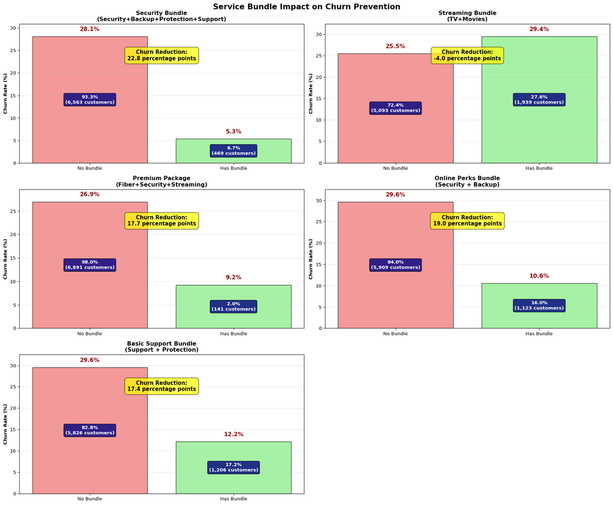

```
📊 BUNDLE EFFECTIVENESS SUMMARY:
--------------------------------------------------

🎯 Security Bundle (Security+Backup+Protection+Support):
   • Adoption Rate: 6.7% (469 customers)
   • Without Bundle: 28.1% churn
   • With Bundle: 5.3% churn
   • Churn Reduction: 22.8 percentage points
   • Effectiveness: 81.0% improvement

🎯 Streaming Bundle (TV+Movies):
   • Adoption Rate: 27.6% (1,939 customers)
   • Without Bundle: 25.5% churn
   • With Bundle: 29.4% churn
   • Churn Reduction: -4.0 percentage points
   • Effectiveness: -15.5% improvement

🎯 Premium Package (Fiber+Security+Streaming):
   • Adoption Rate: 2.0% (141 customers)
   • Without Bundle: 26.9% churn
   • With Bundle: 9.2% churn
   • Churn Reduction: 17.7 percentage points
   • Effectiveness: 65.8% improvement

🎯 Online Perks Bundle (Security + Backup):
   • Adoption Rate: 16.0% (1,123 customers)
   • Without Bundle: 29.6% churn
   • With Bundle: 10.6% churn
   • Churn Reduction: 19.0 percentage points
   • Effectiveness: 64.2% improvement

🎯 Basic Support Bundle (Support + Protection):
   • Adoption Rate: 17.2% (1,206 customers)
   • Without Bundle: 29.6% churn
   • With Bundle: 12.2% churn
   • Churn Reduction: 17.4 percentage points
   • Effectiveness: 58.8% improvement
```

```python
# Service Combinations Analysis - Which bundles prevent churn best?
print("\n" + "="*70)
print("🎯 SERVICE COMBINATIONS ANALYSIS")
print("="*70)

# Define security/support bundle (most protective services)
df_clean['SecurityBundle'] = ((df_clean['OnlineSecurity'] == 'Yes') &
                             (df_clean['OnlineBackup'] == 'Yes') &
                             (df_clean['DeviceProtection'] == 'Yes') &
                             (df_clean['TechSupport'] == 'Yes')).astype(int)

# Define online bundle (online services only)
df_clean['OnlinePerksBundle'] = ((df_clean['OnlineSecurity'] == 'Yes') &
                             (df_clean['OnlineBackup'] == 'Yes')).astype(int)

#Define Support and Protection Bundle
df_clean['BasicSupportBundle'] = ((df_clean['DeviceProtection'] == 'Yes') &
                             (df_clean['TechSupport'] == 'Yes')).astype(int)

# Define streaming bundle
df_clean['StreamingBundle'] = ((df_clean['StreamingTV'] == 'Yes') &
                              (df_clean['StreamingMovies'] == 'Yes')).astype(int)

# Define premium package (fiber + security + streaming)
df_clean['PremiumPackage'] = ((df_clean['InternetService'] == 'Fiber optic') &
                             (df_clean['SecurityBundle'] == 1) &
                             (df_clean['StreamingBundle'] == 1)).astype(int)

# Analyze bundle impact
bundle_columns = ['SecurityBundle', 'StreamingBundle', 'PremiumPackage', 'OnlinePerksBundle', 'BasicSupportBundle']
bundle_names = ['Security Bundle\n(Security+Backup+Protection+Support)',
                'Streaming Bundle\n(TV+Movies)',
                'Premium Package\n(Fiber+Security+Streaming)',
                'Online Perks Bundle\n(Security + Backup)',
                'Basic Support Bundle\n(Support + Protection)'
                ]

# Create bundle analysis visualization
fig, axes = plt.subplots(3, 2, figsize=(18, 15))
fig.suptitle('Service Bundle Impact on Churn Prevention', fontsize=16, fontweight='bold')

# Hide the empty 6th subplot (bottom right)
axes[2, 1].set_visible(False)

for idx, (bundle_col, bundle_name) in enumerate(zip(bundle_columns, bundle_names)):
    row = idx // 2
    col = idx % 2
    ax = axes[row, col]

    # Calculate churn rates for bundle vs no bundle
    bundle_churn = pd.crosstab(df_clean[bundle_col], df_clean['Churn'], normalize='index') * 100
    bundle_counts = df_clean[bundle_col].value_counts()
    bundle_distribution = df_clean[bundle_col].value_counts(normalize=True) * 100

    # Create bar plot
    x_labels = ['No Bundle', 'Has Bundle']
    x_pos = [0, 1]
    colors = ['lightcoral', 'lightgreen']

    bars = ax.bar(x_pos, bundle_churn['Yes'], color=colors, alpha=0.8, edgecolor='black', linewidth=1)

    # Add labels
    for i, bar in enumerate(bars):
        height = bar.get_height()
        bundle_status = bundle_churn.index[i]

        # Churn rate above bar
        ax.text(bar.get_x() + bar.get_width()/2., height + 1,
                f'{height:.1f}%', ha='center', va='bottom',
                fontweight='bold', fontsize=12, color='darkred')

        # Customer distribution inside bar
        customer_count = bundle_counts[bundle_status]
        distribution_pct = bundle_distribution[bundle_status]

        ax.text(bar.get_x() + bar.get_width()/2., height/2,
                f'{distribution_pct:.1f}%\n({customer_count:,} customers)',
                ha='center', va='center', fontweight='bold', fontsize=10,
                color='white', bbox=dict(boxstyle='round,pad=0.3', facecolor='navy', alpha=0.8))

    # Calculate savings
    churn_reduction = bundle_churn.loc[0, 'Yes'] - bundle_churn.loc[1, 'Yes']
    ax.text(0.5, max(bundle_churn['Yes']) * 0.85,
            f'Churn Reduction:\n{churn_reduction:.1f} percentage points',
            ha='center', va='center', fontsize=11, fontweight='bold',
            bbox=dict(boxstyle='round,pad=0.5', facecolor='yellow', alpha=0.7))

    ax.set_title(bundle_name, fontweight='bold', fontsize=12)
    ax.set_ylabel('Churn Rate (%)', fontweight='bold')
    ax.set_xticks(x_pos)
    ax.set_xticklabels(x_labels)
    ax.grid(axis='y', alpha=0.3)
    ax.set_ylim(0, max(bundle_churn['Yes']) * 1.1)

plt.tight_layout()
plt.show()

# Print bundle analysis summary
print(f"\n📊 BUNDLE EFFECTIVENESS SUMMARY:")
print("-" * 50)

for bundle_col, bundle_name in zip(bundle_columns, bundle_names):
    bundle_churn = pd.crosstab(df_clean[bundle_col], df_clean['Churn'], normalize='index') * 100
    bundle_counts = df_clean[bundle_col].value_counts()

    no_bundle_churn = bundle_churn.loc[0, 'Yes']
    has_bundle_churn = bundle_churn.loc[1, 'Yes'] if 1 in bundle_churn.index else 0
    churn_reduction = no_bundle_churn - has_bundle_churn

    customers_with_bundle = bundle_counts.get(1, 0)
    total_customers = len(df_clean)
    adoption_rate = (customers_with_bundle / total_customers) * 100

    print(f"\n🎯 {bundle_name.replace(chr(10), ' ')}:")
    print(f"   • Adoption Rate: {adoption_rate:.1f}% ({customers_with_bundle:,} customers)")
    print(f"   • Without Bundle: {no_bundle_churn:.1f}% churn")
    print(f"   • With Bundle: {has_bundle_churn:.1f}% churn")
    print(f"   • Churn Reduction: {churn_reduction:.1f} percentage points")
    print(f"   • Effectiveness: {((churn_reduction/no_bundle_churn)*100):.1f}% improvement")
```

# 3 Demographic + Service Combinations Analysis

**Advanced Analysis Focus**

Understanding how customer demographics interact with service usage patterns provides deeper insights for targeted retention strategies and personalized service offerings.

## 3.1 Understanding How Customer Demographics Interact with Service Usage Patterns

**Click to view demographic + service combinations setup**

```python
# Demographic + Service Combinations Setup
print("=== DEMOGRAPHIC + SERVICE COMBINATIONS ANALYSIS ===")
print("Analyzing how different customer demographics interact with service usage patterns")

# First, ensure we have all necessary demographic variables
# Create SeniorCitizen_Label if not exists
if 'SeniorCitizen_Label' not in df_clean.columns:
    df_clean['SeniorCitizen_Label'] = df_clean['SeniorCitizen'].map({0: 'No', 1: 'Yes'})

# Create LifeStage variable if not exists
if 'LifeStage' not in df_clean.columns:
    def determine_life_stage(row):
        if row['SeniorCitizen'] == 1:
            return 'Senior Individual' if row['Partner'] == 'No' else 'Senior Couple'
        else:
            if row['Partner'] == 'No':
                return 'Young Individual'
            elif row['Dependents'] == 'Yes':
                return 'Young Family'
            else:
                return 'Young Couple'

    df_clean['LifeStage'] = df_clean.apply(determine_life_stage, axis=1)

# Create service bundle variables if not exist
bundle_definitions = {
    'SecurityBundle': ['OnlineSecurity', 'OnlineBackup', 'DeviceProtection'],
    'StreamingBundle': ['StreamingTV', 'StreamingMovies'],
    'OnlinePerksBundle': ['OnlineSecurity', 'OnlineBackup', 'TechSupport'],
    'BasicSupportBundle': ['TechSupport', 'DeviceProtection']
}

for bundle_name, services in bundle_definitions.items():
    if bundle_name not in df_clean.columns:
        df_clean[bundle_name] = (df_clean[services] == 'Yes').sum(axis=1).apply(lambda x: 1 if x >= len(services) else 0)

# Define the service features we'll analyze
service_features = ['PhoneService', 'MultipleLines', 'InternetService', 'OnlineSecurity',
                   'OnlineBackup', 'DeviceProtection', 'TechSupport', 'StreamingTV', 'StreamingMovies']

demographic_features = ['gender', 'SeniorCitizen_Label', 'Partner', 'Dependents', 'LifeStage']

print(f"\n📊 Analysis Scope:")
print(f"   • Service Features: {len(service_features)} services")
print(f"   • Demographic Features: {len(demographic_features)} demographics")
print(f"   • Total Customers: {len(df_clean):,}")
print(f"   • Focus: Understanding interaction effects on churn")
print(f"   • Life Stages: {sorted(df_clean['LifeStage'].unique())}")
```

```
=== DEMOGRAPHIC + SERVICE COMBINATIONS ANALYSIS ===
Analyzing how different customer demographics interact with service usage patterns

📊 Analysis Scope:
   • Service Features: 9 services
   • Demographic Features: 5 demographics
   • Total Customers: 7,032
   • Focus: Understanding interaction effects on churn
   • Life Stages: ['Senior Couple', 'Senior Individual', 'Young Couple', 'Young Family', 'Young Individual']
```

## 3.2 Service Adoption by Life Stage

**Life Stage Service Preferences**

Different customer life stages show distinct service adoption patterns, revealing opportunities for targeted service bundles and marketing strategies.

```
=== SERVICE ADOPTION BY LIFE STAGE ===
```

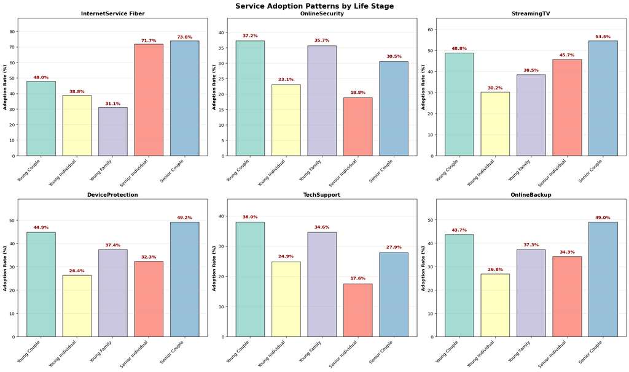

```
📊 SERVICE ADOPTION ANALYSIS BY LIFE STAGE:
================================================================================

🎯 YOUNG COUPLE (1,163 customers):
   • StreamingMovies: 49.1% - 🟡 Medium Adoption
   • StreamingTV: 48.8% - 🟡 Medium Adoption
   • InternetService Fiber: 48.0% - 🟡 Medium Adoption
   • DeviceProtection: 44.9% - 🟡 Medium Adoption
   • OnlineBackup: 43.7% - 🟡 Medium Adoption
   • TechSupport: 38.0% - 🟡 Medium Adoption
   • OnlineSecurity: 37.2% - 🟡 Medium Adoption
   • InternetService DSL: 35.9% - 🟡 Medium Adoption

🎯 YOUNG INDIVIDUAL (3,070 customers):
   • InternetService Fiber: 38.8% - 🟡 Medium Adoption
   • InternetService DSL: 36.4% - 🟡 Medium Adoption
   • StreamingMovies: 30.9% - 🟡 Medium Adoption
   • StreamingTV: 30.2% - 🟡 Medium Adoption
   • OnlineBackup: 26.8% - 🟡 Medium Adoption
   • DeviceProtection: 26.4% - 🟡 Medium Adoption
   • TechSupport: 24.9% - 🔴 Low Adoption
   • OnlineSecurity: 23.1% - 🔴 Low Adoption

🎯 YOUNG FAMILY (1,657 customers):
   • StreamingTV: 38.5% - 🟡 Medium Adoption
   • InternetService DSL: 37.7% - 🟡 Medium Adoption
   • DeviceProtection: 37.4% - 🟡 Medium Adoption
   • OnlineBackup: 37.3% - 🟡 Medium Adoption
   • StreamingMovies: 37.1% - 🟡 Medium Adoption
   • OnlineSecurity: 35.7% - 🟡 Medium Adoption
   • TechSupport: 34.6% - 🟡 Medium Adoption
   • InternetService Fiber: 31.1% - 🟡 Medium Adoption

🎯 SENIOR INDIVIDUAL (569 customers):
   • InternetService Fiber: 71.7% - 🟢 High Adoption
   • StreamingMovies: 45.9% - 🟡 Medium Adoption
   • StreamingTV: 45.7% - 🟡 Medium Adoption
   • OnlineBackup: 34.3% - 🟡 Medium Adoption
   • DeviceProtection: 32.3% - 🟡 Medium Adoption
   • InternetService DSL: 23.9% - 🔴 Low Adoption
   • OnlineSecurity: 18.8% - 🔴 Low Adoption
   • TechSupport: 17.6% - 🔴 Low Adoption

🎯 SENIOR COUPLE (573 customers):
   • InternetService Fiber: 73.8% - 🟢 High Adoption
   • StreamingMovies: 58.3% - 🟢 High Adoption
   • StreamingTV: 54.5% - 🟢 High Adoption
   • DeviceProtection: 49.2% - 🟡 Medium Adoption
   • OnlineBackup: 49.0% - 🟡 Medium Adoption
   • OnlineSecurity: 30.5% - 🟡 Medium Adoption
   • TechSupport: 27.9% - 🟡 Medium Adoption
   • InternetService DSL: 21.5% - 🔴 Low Adoption

💡 KEY INSIGHTS:
   • Different life stages show distinct service preferences
   • Young families may prefer different services than seniors
   • Service bundles should be tailored to life stage needs
```

```python
# Service Adoption Patterns by Life Stage
print("=== SERVICE ADOPTION BY LIFE STAGE ===")

# Calculate service adoption rates by life stage
life_stages = df_clean['LifeStage'].unique()
services_to_analyze = ['InternetService', 'OnlineSecurity', 'OnlineBackup', 'DeviceProtection',
                      'TechSupport', 'StreamingTV', 'StreamingMovies']

# Create a comprehensive service adoption analysis
service_adoption_by_lifestage = {}

for life_stage in life_stages:
    life_stage_customers = df_clean[df_clean['LifeStage'] == life_stage]
    adoption_rates = {}

    for service in services_to_analyze:
        if service == 'InternetService':
            # For InternetService, we'll look at Fiber optic adoption
            adoption_rate = (life_stage_customers[service] == 'Fiber optic').mean() * 100
            adoption_rates[f'{service}_Fiber'] = adoption_rate
            adoption_rate_dsl = (life_stage_customers[service] == 'DSL').mean() * 100
            adoption_rates[f'{service}_DSL'] = adoption_rate_dsl
        else:
            # For other services, look at "Yes" adoption
            adoption_rate = (life_stage_customers[service] == 'Yes').mean() * 100
            adoption_rates[service] = adoption_rate

    service_adoption_by_lifestage[life_stage] = adoption_rates

# Create visualization
fig, axes = plt.subplots(2, 3, figsize=(20, 12))
fig.suptitle('Service Adoption Patterns by Life Stage', fontsize=16, fontweight='bold')

# Flatten axes for easier iteration
axes_flat = axes.flatten()

services_to_plot = ['InternetService_Fiber', 'OnlineSecurity', 'StreamingTV',
                   'DeviceProtection', 'TechSupport', 'OnlineBackup']

for idx, service in enumerate(services_to_plot):
    ax = axes_flat[idx]

    # Get adoption rates for this service across life stages
    life_stage_names = []
    adoption_rates = []

    for life_stage in life_stages:
        life_stage_names.append(life_stage)
        adoption_rates.append(service_adoption_by_lifestage[life_stage].get(service, 0))

    # Create bar plot
    colors = plt.cm.Set3(range(len(life_stage_names)))
    bars = ax.bar(range(len(life_stage_names)), adoption_rates, color=colors, alpha=0.8, edgecolor='black')

    # Add labels
    for i, bar in enumerate(bars):
        height = bar.get_height()
        ax.text(bar.get_x() + bar.get_width()/2., height + 1,
                f'{height:.1f}%', ha='center', va='bottom',
                fontweight='bold', fontsize=10, color='darkred')

    ax.set_title(service.replace('_', ' '), fontweight='bold', fontsize=12)
    ax.set_ylabel('Adoption Rate (%)', fontweight='bold')
    ax.set_xticks(range(len(life_stage_names)))
    ax.set_xticklabels(life_stage_names, rotation=45, ha='right')
    ax.grid(axis='y', alpha=0.3)
    ax.set_ylim(0, max(adoption_rates) * 1.2)

plt.tight_layout()
plt.show()

# Print detailed analysis
print(f"\n📊 SERVICE ADOPTION ANALYSIS BY LIFE STAGE:")
print("="*80)

for life_stage in life_stages:
    life_stage_count = len(df_clean[df_clean['LifeStage'] == life_stage])
    print(f"\n🎯 {life_stage.upper()} ({life_stage_count:,} customers):")

    adoption_data = service_adoption_by_lifestage[life_stage]

    # Sort services by adoption rate
    sorted_services = sorted(adoption_data.items(), key=lambda x: x[1], reverse=True)

    for service, rate in sorted_services:
        if rate > 50:
            trend = "🟢 High Adoption"
        elif rate > 25:
            trend = "🟡 Medium Adoption"
        else:
            trend = "🔴 Low Adoption"

        print(f"   • {service.replace('_', ' ')}: {rate:.1f}% - {trend}")

print(f"\n💡 KEY INSIGHTS:")
print(f"   • Different life stages show distinct service preferences")
print(f"   • Young families may prefer different services than seniors")
print(f"   • Service bundles should be tailored to life stage needs")
```

## 3.3 Demographic-Specific Service Bundle Effectiveness

**Bundle Performance Varies by Demographics**

Service bundles show dramatically different effectiveness across customer demographics, with some combinations reducing churn by over 30 percentage points.

```
=== SERVICE BUNDLE EFFECTIVENESS BY DEMOGRAPHICS ===

🎯 BUNDLE EFFECTIVENESS BY LIFE STAGE:
======================================================================
```

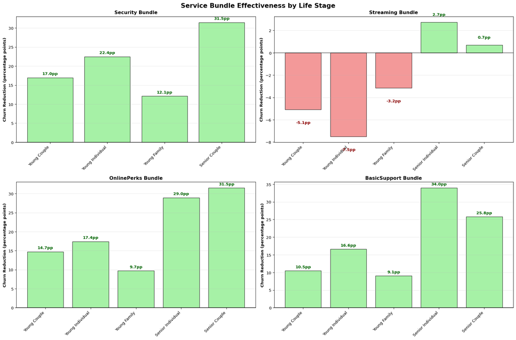

```
🎯 YOUNG COUPLE:
   📊 Base Churn Rate: 20.8%
   📦 Bundle Effectiveness:
      • Security: 17.0pp reduction, 9.5% adoption - 🟢 Highly Effective
      • Streaming: -5.1pp reduction, 37.7% adoption - 🔴 Not Effective
      • OnlinePerks: 14.7pp reduction, 22.1% adoption - 🟢 Highly Effective
      • BasicSupport: 10.5pp reduction, 23.6% adoption - 🟢 Highly Effective

🎯 YOUNG INDIVIDUAL:
   📊 Base Churn Rate: 30.0%
   📦 Bundle Effectiveness:
      • Security: 22.4pp reduction, 4.2% adoption - 🟢 Highly Effective
      • Streaming: -7.5pp reduction, 20.3% adoption - 🔴 Not Effective
      • OnlinePerks: 17.4pp reduction, 11.2% adoption - 🟢 Highly Effective
      • BasicSupport: 16.6pp reduction, 12.8% adoption - 🟢 Highly Effective

🎯 YOUNG FAMILY:
   📊 Base Churn Rate: 13.8%
   📦 Bundle Effectiveness:
      • Security: 12.1pp reduction, 10.2% adoption - 🟢 Highly Effective
      • Streaming: -3.2pp reduction, 27.3% adoption - 🔴 Not Effective
      • OnlinePerks: 9.7pp reduction, 21.5% adoption - 🟢 Highly Effective
      • BasicSupport: 9.1pp reduction, 22.3% adoption - 🟢 Highly Effective

🎯 SENIOR INDIVIDUAL:
   📊 Base Churn Rate: 48.9%
   📦 Bundle Effectiveness:
      • Streaming: 2.7pp reduction, 32.2% adoption - 🟡 Moderately Effective
      • OnlinePerks: 29.0pp reduction, 10.0% adoption - 🟢 Highly Effective
      • BasicSupport: 34.0pp reduction, 9.7% adoption - 🟢 Highly Effective

🎯 SENIOR COUPLE:
   📊 Base Churn Rate: 34.6%
   📦 Bundle Effectiveness:
      • Security: 31.5pp reduction, 8.9% adoption - 🟢 Highly Effective
      • Streaming: 0.7pp reduction, 42.4% adoption - 🟡 Moderately Effective
      • OnlinePerks: 31.5pp reduction, 19.2% adoption - 🟢 Highly Effective
      • BasicSupport: 25.8pp reduction, 20.1% adoption - 🟢 Highly Effective

💡 KEY DEMOGRAPHIC + SERVICE INSIGHTS:
   • Service bundles show different effectiveness across life stages
   • Some demographics benefit more from specific service combinations
   • Targeted bundle recommendations can improve retention
   • Life stage-specific service strategies are needed
```

```python
# Service Bundle Effectiveness by Demographics
print("=== SERVICE BUNDLE EFFECTIVENESS BY DEMOGRAPHICS ===")

# Analyze how service bundles perform differently across demographic groups
bundles_to_analyze = ['SecurityBundle', 'StreamingBundle', 'OnlinePerksBundle', 'BasicSupportBundle']

# Create analysis for each demographic + bundle combination
demographic_bundle_analysis = {}

for demographic in ['LifeStage', 'SeniorCitizen_Label', 'Partner', 'Dependents']:
    demographic_bundle_analysis[demographic] = {}

    for bundle in bundles_to_analyze:
        demo_bundle_results = {}

        for demo_value in df_clean[demographic].unique():
            demo_customers = df_clean[df_clean[demographic] == demo_value]

            # Calculate churn rates for customers with and without the bundle
            bundle_effectiveness = {}

            # Customers with bundle
            with_bundle = demo_customers[demo_customers[bundle] == 1]
            without_bundle = demo_customers[demo_customers[bundle] == 0]

            if len(with_bundle) > 10 and len(without_bundle) > 10:  # Minimum sample size
                churn_with_bundle = (with_bundle['Churn'] == 'Yes').mean() * 100
                churn_without_bundle = (without_bundle['Churn'] == 'Yes').mean() * 100
                churn_reduction = churn_without_bundle - churn_with_bundle

                bundle_effectiveness = {
                    'with_bundle_churn': churn_with_bundle,
                    'without_bundle_churn': churn_without_bundle,
                    'churn_reduction': churn_reduction,
                    'customers_with_bundle': len(with_bundle),
                    'customers_without_bundle': len(without_bundle),
                    'bundle_adoption_rate': (len(with_bundle) / len(demo_customers)) * 100
                }

            demo_bundle_results[demo_value] = bundle_effectiveness

        demographic_bundle_analysis[demographic][bundle] = demo_bundle_results

# Visualize the most interesting findings
print(f"\n🎯 BUNDLE EFFECTIVENESS BY LIFE STAGE:")
print("="*70)

life_stage_bundle_data = demographic_bundle_analysis['LifeStage']

# Create a comprehensive visualization
fig, axes = plt.subplots(2, 2, figsize=(18, 12))
fig.suptitle('Service Bundle Effectiveness by Life Stage', fontsize=16, fontweight='bold')

axes_flat = axes.flatten()

for idx, bundle in enumerate(bundles_to_analyze):
    ax = axes_flat[idx]
    bundle_data = life_stage_bundle_data[bundle]

    life_stages_with_data = [ls for ls in life_stages if bundle_data.get(ls) and bundle_data[ls]]
    churn_reductions = [bundle_data[ls]['churn_reduction'] for ls in life_stages_with_data if bundle_data[ls]]

    if churn_reductions:
        colors = ['lightgreen' if cr > 0 else 'lightcoral' for cr in churn_reductions]
        bars = ax.bar(range(len(life_stages_with_data)), churn_reductions,
                     color=colors, alpha=0.8, edgecolor='black')

        # Add labels
        for i, bar in enumerate(bars):
            height = bar.get_height()
            ax.text(bar.get_x() + bar.get_width()/2., height + (0.5 if height > 0 else -1),
                    f'{height:.1f}pp', ha='center', va='bottom' if height > 0 else 'top',
                    fontweight='bold', fontsize=10, color='darkgreen' if height > 0 else 'darkred')

        ax.set_title(bundle.replace('Bundle', ' Bundle'), fontweight='bold', fontsize=12)
        ax.set_ylabel('Churn Reduction (percentage points)', fontweight='bold')
        ax.set_xticks(range(len(life_stages_with_data)))
        ax.set_xticklabels(life_stages_with_data, rotation=45, ha='right')
        ax.grid(axis='y', alpha=0.3)
        ax.axhline(y=0, color='black', linestyle='-', alpha=0.5)

plt.tight_layout()
plt.show()

# Print detailed analysis
for life_stage in life_stages:
    print(f"\n🎯 {life_stage.upper()}:")

    life_stage_customers = df_clean[df_clean['LifeStage'] == life_stage]
    life_stage_churn = (life_stage_customers['Churn'] == 'Yes').mean() * 100

    print(f"   📊 Base Churn Rate: {life_stage_churn:.1f}%")
    print(f"   📦 Bundle Effectiveness:")

    for bundle in bundles_to_analyze:
        bundle_data = life_stage_bundle_data[bundle].get(life_stage, {})

        if bundle_data:
            reduction = bundle_data['churn_reduction']
            adoption = bundle_data['bundle_adoption_rate']

            if reduction > 5:
                effectiveness = "🟢 Highly Effective"
            elif reduction > 0:
                effectiveness = "🟡 Moderately Effective"
            else:
                effectiveness = "🔴 Not Effective"

            print(f"      • {bundle.replace('Bundle', '')}: {reduction:.1f}pp reduction, {adoption:.1f}% adoption - {effectiveness}")

print(f"\n💡 KEY DEMOGRAPHIC + SERVICE INSIGHTS:")
print(f"   • Service bundles show different effectiveness across life stages")
print(f"   • Some demographics benefit more from specific service combinations")
print(f"   • Targeted bundle recommendations can improve retention")
print(f"   • Life stage-specific service strategies are needed")
```

## 3.4 Service Usage Patterns by Gender and Age

**Gender and Age Impact Service Preferences**

Senior customers show significantly different service adoption patterns, with much higher preference for fiber optic internet and streaming services compared to younger demographics.

```
=== SERVICE USAGE BY GENDER AND AGE ===
```

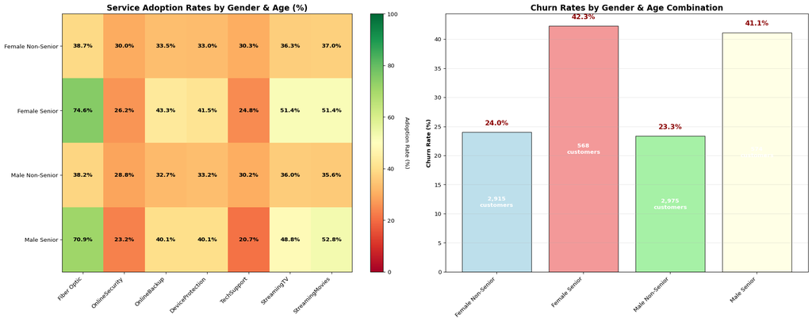

```
📊 GENDER & AGE SERVICE PREFERENCES:
================================================================================

🎯 FEMALE NON-SENIOR (2,915 customers):
   ⚠️  Churn Rate: 24.0%
   📱 Service Preferences:
      • Fiber Optic: 38.7% - 🟡 Medium
      • StreamingMovies: 37.0% - 🟡 Medium
      • DSL: 36.4% - 🟡 Medium
      • StreamingTV: 36.3% - 🟡 Medium
      • OnlineBackup: 33.5% - 🟡 Medium

🎯 FEMALE SENIOR (568 customers):
   ⚠️  Churn Rate: 42.3%
   📱 Service Preferences:
      • Fiber Optic: 74.6% - 🟢 High
      • StreamingTV: 51.4% - 🟢 High
      • StreamingMovies: 51.4% - 🟢 High
      • OnlineBackup: 43.3% - 🟡 Medium
      • DeviceProtection: 41.5% - 🟡 Medium

🎯 MALE NON-SENIOR (2,975 customers):
   ⚠️  Churn Rate: 23.3%
   📱 Service Preferences:
      • Fiber Optic: 38.2% - 🟡 Medium
      • DSL: 36.8% - 🟡 Medium
      • StreamingTV: 36.0% - 🟡 Medium
      • StreamingMovies: 35.6% - 🟡 Medium
      • DeviceProtection: 33.2% - 🟡 Medium

🎯 MALE SENIOR (574 customers):
   ⚠️  Churn Rate: 41.1%
   📱 Service Preferences:
      • Fiber Optic: 70.9% - 🟢 High
      • StreamingMovies: 52.8% - 🟢 High
      • StreamingTV: 48.8% - 🟡 Medium
      • OnlineBackup: 40.1% - 🟡 Medium
      • DeviceProtection: 40.1% - 🟡 Medium

🔍 KEY GENDER & AGE INSIGHTS:

📈 SENIOR vs NON-SENIOR SERVICE PREFERENCES:
   • Fiber Optic: Seniors prefer this service (+34.3pp difference)
   • StreamingTV: Seniors prefer this service (+13.9pp difference)
   • StreamingMovies: Seniors prefer this service (+15.8pp difference)

💡 STRATEGIC IMPLICATIONS:
   • Service preferences vary significantly by gender and age
   • Senior customers have different technology adoption patterns
   • Gender-specific service packages could improve satisfaction
   • Age-appropriate service recommendations are crucial
```

```python
# Service Usage Patterns by Gender and Age
print("=== SERVICE USAGE BY GENDER AND AGE ===")

# Analyze service preferences by gender and senior status
gender_age_combinations = [
    ('Female', 'No'), ('Female', 'Yes'),
    ('Male', 'No'), ('Male', 'Yes')
]

# Calculate service usage for each combination
service_usage_matrix = {}

services_for_analysis = ['InternetService', 'OnlineSecurity', 'OnlineBackup',
                        'DeviceProtection', 'TechSupport', 'StreamingTV', 'StreamingMovies']

for gender, senior_status in gender_age_combinations:
    combo_name = f"{gender} {'Senior' if senior_status == 'Yes' else 'Non-Senior'}"
    customers = df_clean[(df_clean['gender'] == gender) &
                        (df_clean['SeniorCitizen_Label'] == senior_status)]

    service_stats = {}
    for service in services_for_analysis:
        if service == 'InternetService':
            # Look at internet service types
            service_stats['Fiber_Optic'] = (customers[service] == 'Fiber optic').mean() * 100
            service_stats['DSL'] = (customers[service] == 'DSL').mean() * 100
            service_stats['No_Internet'] = (customers[service] == 'No').mean() * 100
        else:
            service_stats[service] = (customers[service] == 'Yes').mean() * 100

    # Add churn rate and customer count
    service_stats['Churn_Rate'] = (customers['Churn'] == 'Yes').mean() * 100
    service_stats['Customer_Count'] = len(customers)

    service_usage_matrix[combo_name] = service_stats

# Create heatmap visualization
fig, (ax1, ax2) = plt.subplots(1, 2, figsize=(20, 8))

# Service adoption heatmap
services_for_heatmap = ['Fiber_Optic', 'OnlineSecurity', 'OnlineBackup',
                       'DeviceProtection', 'TechSupport', 'StreamingTV', 'StreamingMovies']

heatmap_data = []
combo_labels = []

for combo_name in service_usage_matrix.keys():
    combo_labels.append(combo_name)
    row_data = [service_usage_matrix[combo_name].get(service, 0) for service in services_for_heatmap]
    heatmap_data.append(row_data)

import numpy as np
heatmap_array = np.array(heatmap_data)

# Create heatmap
im1 = ax1.imshow(heatmap_array, cmap='RdYlGn', aspect='auto', vmin=0, vmax=100)
ax1.set_xticks(range(len(services_for_heatmap)))
ax1.set_xticklabels([s.replace('_', ' ') for s in services_for_heatmap], rotation=45, ha='right')
ax1.set_yticks(range(len(combo_labels)))
ax1.set_yticklabels(combo_labels)
ax1.set_title('Service Adoption Rates by Gender & Age (%)', fontweight='bold', fontsize=14)

# Add text annotations
for i in range(len(combo_labels)):
    for j in range(len(services_for_heatmap)):
        text = ax1.text(j, i, f'{heatmap_array[i, j]:.1f}%',
                       ha="center", va="center", color="black", fontweight='bold')

# Add colorbar
cbar1 = plt.colorbar(im1, ax=ax1)
cbar1.set_label('Adoption Rate (%)', rotation=270, labelpad=20)

# Churn rates comparison
churn_rates = [service_usage_matrix[combo]['Churn_Rate'] for combo in combo_labels]
customer_counts = [service_usage_matrix[combo]['Customer_Count'] for combo in combo_labels]

colors = ['lightblue', 'lightcoral', 'lightgreen', 'lightyellow']
bars = ax2.bar(range(len(combo_labels)), churn_rates, color=colors, alpha=0.8, edgecolor='black')

# Add labels
for i, bar in enumerate(bars):
    height = bar.get_height()
    ax2.text(bar.get_x() + bar.get_width()/2., height + 1,
            f'{height:.1f}%', ha='center', va='bottom',
            fontweight='bold', fontsize=12, color='darkred')

    ax2.text(bar.get_x() + bar.get_width()/2., height/2,
            f'{customer_counts[i]:,}\ncustomers',
            ha='center', va='center', fontweight='bold', fontsize=10,
            color='white' if height > 15 else 'black')

ax2.set_title('Churn Rates by Gender & Age Combination', fontweight='bold', fontsize=14)
ax2.set_ylabel('Churn Rate (%)', fontweight='bold')
ax2.set_xticks(range(len(combo_labels)))
ax2.set_xticklabels(combo_labels, rotation=45, ha='right')
ax2.grid(axis='y', alpha=0.3)

plt.tight_layout()
plt.show()

# Print detailed analysis
print(f"\n📊 GENDER & AGE SERVICE PREFERENCES:")
print("="*80)

for combo_name, stats in service_usage_matrix.items():
    print(f"\n🎯 {combo_name.upper()} ({stats['Customer_Count']:,} customers):")
    print(f"   ⚠️  Churn Rate: {stats['Churn_Rate']:.1f}%")
    print(f"   📱 Service Preferences:")

    # Sort services by adoption rate
    service_prefs = [(k, v) for k, v in stats.items()
                    if k not in ['Churn_Rate', 'Customer_Count'] and v > 0]
    service_prefs.sort(key=lambda x: x[1], reverse=True)

    for service, rate in service_prefs[:5]:  # Top 5 services
        if rate > 50:
            preference = "🟢 High"
        elif rate > 25:
            preference = "🟡 Medium"
        else:
            preference = "🔴 Low"

        print(f"      • {service.replace('_', ' ')}: {rate:.1f}% - {preference}")

# Find the most significant differences
print(f"\n🔍 KEY GENDER & AGE INSIGHTS:")

# Compare seniors vs non-seniors
senior_services = {}
non_senior_services = {}

for combo_name, stats in service_usage_matrix.items():
    if 'Senior' in combo_name and 'Non-Senior' not in combo_name:
        for service in services_for_heatmap:
            senior_services[service] = senior_services.get(service, 0) + stats.get(service, 0)
    elif 'Non-Senior' in combo_name:
        for service in services_for_heatmap:
            non_senior_services[service] = non_senior_services.get(service, 0) + stats.get(service, 0)

print(f"\n📈 SENIOR vs NON-SENIOR SERVICE PREFERENCES:")
for service in services_for_heatmap:
    senior_avg = senior_services[service] / 2  # Average across male/female seniors
    non_senior_avg = non_senior_services[service] / 2  # Average across male/female non-seniors
    difference = senior_avg - non_senior_avg

    if abs(difference) > 10:  # Significant difference
        trend = "prefer" if difference > 0 else "avoid"
        print(f"   • {service.replace('_', ' ')}: Seniors {trend} this service ({difference:+.1f}pp difference)")

print(f"\n💡 STRATEGIC IMPLICATIONS:")
print(f"   • Service preferences vary significantly by gender and age")
print(f"   • Senior customers have different technology adoption patterns")
print(f"   • Gender-specific service packages could improve satisfaction")
print(f"   • Age-appropriate service recommendations are crucial")
```

## 3.5 High-Value Customer Segments (Demographics + Service Combinations)

**Customer Value Segmentation**

By combining demographic characteristics with service usage patterns and financial metrics, we can identify the most valuable customer segments and prioritize retention efforts effectively.

```
=== HIGH-VALUE CUSTOMER SEGMENT IDENTIFICATION ===
Identifying customer segments based on demographics + service combinations + value
```

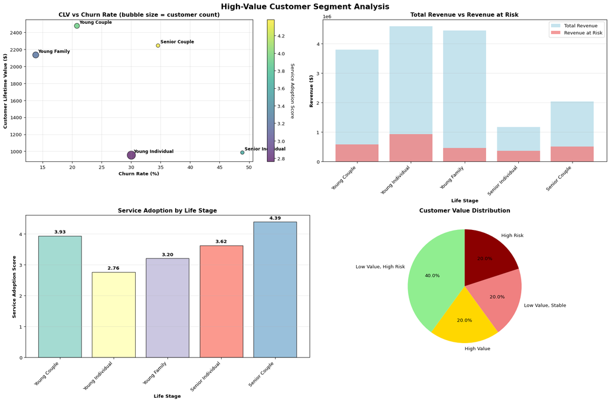

```
📊 CUSTOMER SEGMENT VALUE ANALYSIS:
================================================================================

🎯 YOUNG COUPLE:
   👥 Customer Count: 1,163 (16.5% of base)
   💰 Avg Monthly Charges: $71.70
   📅 Avg Tenure: 43.6 months
   ⚠️  Churn Rate: 20.8%
   🌟 Service Adoption Score: 3.93/7
   💎 Customer Lifetime Value: $2478
   💵 Total Segment Revenue: $3,803,297
   🚨 Revenue at Risk: $578,418 (15.2%)
   🏆 Value Category: High Value

🎯 SENIOR COUPLE:
   👥 Customer Count: 573 (8.1% of base)
   💰 Avg Monthly Charges: $82.78
   📅 Avg Tenure: 41.4 months
   ⚠️  Churn Rate: 34.6%
   🌟 Service Adoption Score: 4.39/7
   💎 Customer Lifetime Value: $2246
   💵 Total Segment Revenue: $2,040,145
   🚨 Revenue at Risk: $514,130 (25.2%)
   🏆 Value Category: High Risk

🎯 YOUNG FAMILY:
   👥 Customer Count: 1,657 (23.6% of base)
   💰 Avg Monthly Charges: $59.97
   📅 Avg Tenure: 41.3 months
   ⚠️  Churn Rate: 13.8%
   🌟 Service Adoption Score: 3.20/7
   💎 Customer Lifetime Value: $2135
   💵 Total Segment Revenue: $4,445,056
   🚨 Revenue at Risk: $463,603 (10.4%)
   🏆 Value Category: Low Value, Stable

🎯 SENIOR INDIVIDUAL:
   👥 Customer Count: 569 (8.1% of base)
   💰 Avg Monthly Charges: $76.84
   📅 Avg Tenure: 25.1 months
```

[output cut: 20 more lines]

```

1. 🟢 HIGH-VALUE SEGMENTS TO PROTECT:
   • Senior Couple: $514,130 at risk (34.6% churn)

2. 🔴 HIGH-RISK SEGMENTS TO RESCUE:
   • Senior Individual: 569 customers at 48.9% churn risk
   • Senior Couple: 573 customers at 34.6% churn risk

3. 💎 UPSELLING OPPORTUNITIES:

💡 STRATEGIC RECOMMENDATIONS:
   ✅ Focus retention efforts on high-CLV segments with elevated churn
   ✅ Develop targeted service bundles for each life stage
   ✅ Implement early warning systems for high-value at-risk customers
   ✅ Create upselling campaigns for low-adoption, high-spend segments
```

```python
# High-Value Customer Segment Analysis
print("=== HIGH-VALUE CUSTOMER SEGMENT IDENTIFICATION ===")
print("Identifying customer segments based on demographics + service combinations + value")

# Create comprehensive customer value analysis
customer_segments = []

for life_stage in life_stages:
    life_stage_customers = df_clean[df_clean['LifeStage'] == life_stage]

    # Calculate multiple value metrics
    avg_monthly_charges = life_stage_customers['MonthlyCharges'].mean()
    avg_total_charges = life_stage_customers['TotalCharges'].mean()
    avg_tenure = life_stage_customers['tenure'].mean()
    churn_rate = (life_stage_customers['Churn'] == 'Yes').mean() * 100
    customer_count = len(life_stage_customers)

    # Calculate service adoption scores
    high_value_services = ['InternetService', 'OnlineSecurity', 'OnlineBackup',
                          'DeviceProtection', 'TechSupport', 'StreamingTV', 'StreamingMovies']

    service_adoption_score = 0
    for service in high_value_services:
        if service == 'InternetService':
            # Give higher score for Fiber optic
            fiber_rate = (life_stage_customers[service] == 'Fiber optic').mean()
            dsl_rate = (life_stage_customers[service] == 'DSL').mean()
            service_adoption_score += (fiber_rate * 2) + (dsl_rate * 1)  # Fiber worth 2x
        else:
            adoption_rate = (life_stage_customers[service] == 'Yes').mean()
            service_adoption_score += adoption_rate

    # Calculate Customer Lifetime Value (simplified)
    # CLV = Average Monthly Revenue × Average Tenure × (1 - Churn Rate)
    clv = avg_monthly_charges * avg_tenure * (1 - churn_rate/100)

    # Calculate total revenue for this segment
    total_segment_revenue = life_stage_customers['TotalCharges'].sum()
    revenue_at_risk = life_stage_customers[life_stage_customers['Churn'] == 'Yes']['TotalCharges'].sum()

    customer_segments.append({
        'LifeStage': life_stage,
        'CustomerCount': customer_count,
        'AvgMonthlyCharges': avg_monthly_charges,
        'AvgTotalCharges': avg_total_charges,
        'AvgTenure': avg_tenure,
        'ChurnRate': churn_rate,
        'ServiceAdoptionScore': service_adoption_score,
        'CLV': clv,
        'TotalSegmentRevenue': total_segment_revenue,
        'RevenueAtRisk': revenue_at_risk,
        'RevenueAtRiskPct': (revenue_at_risk / total_segment_revenue) * 100 if total_segment_revenue > 0 else 0
    })

# Convert to DataFrame for easier analysis
segments_df = pd.DataFrame(customer_segments)

# Create comprehensive visualization
fig, axes = plt.subplots(2, 2, figsize=(18, 12))
fig.suptitle('High-Value Customer Segment Analysis', fontsize=16, fontweight='bold')

# 1. Customer Lifetime Value vs Churn Rate
ax1 = axes[0, 0]
scatter = ax1.scatter(segments_df['ChurnRate'], segments_df['CLV'],
                     s=segments_df['CustomerCount']/10,
                     c=segments_df['ServiceAdoptionScore'],
                     cmap='viridis', alpha=0.7, edgecolors='black')

for i, row in segments_df.iterrows():
    ax1.annotate(row['LifeStage'], (row['ChurnRate'], row['CLV']),
                xytext=(5, 5), textcoords='offset points', fontsize=9, fontweight='bold')

ax1.set_xlabel('Churn Rate (%)', fontweight='bold')
ax1.set_ylabel('Customer Lifetime Value ($)', fontweight='bold')
ax1.set_title('CLV vs Churn Rate (bubble size = customer count)', fontweight='bold')
ax1.grid(True, alpha=0.3)

# Add colorbar
cbar = plt.colorbar(scatter, ax=ax1)
cbar.set_label('Service Adoption Score', rotation=270, labelpad=20)

# 2. Total Revenue vs Revenue at Risk
ax2 = axes[0, 1]
bars = ax2.bar(range(len(segments_df)), segments_df['TotalSegmentRevenue'],
               color='lightblue', alpha=0.7, label='Total Revenue')
bars2 = ax2.bar(range(len(segments_df)), segments_df['RevenueAtRisk'],
                color='lightcoral', alpha=0.8, label='Revenue at Risk')

ax2.set_xlabel('Life Stage', fontweight='bold')
ax2.set_ylabel('Revenue ($)', fontweight='bold')
ax2.set_title('Total Revenue vs Revenue at Risk', fontweight='bold')
ax2.set_xticks(range(len(segments_df)))
ax2.set_xticklabels(segments_df['LifeStage'], rotation=45, ha='right')
ax2.legend()
ax2.grid(axis='y', alpha=0.3)

# 3. Service Adoption Score
ax3 = axes[1, 0]
colors = plt.cm.Set3(range(len(segments_df)))
bars = ax3.bar(range(len(segments_df)), segments_df['ServiceAdoptionScore'],
               color=colors, alpha=0.8, edgecolor='black')

for i, bar in enumerate(bars):
    height = bar.get_height()
    ax3.text(bar.get_x() + bar.get_width()/2., height + 0.05,
            f'{height:.2f}', ha='center', va='bottom',
            fontweight='bold', fontsize=10)

ax3.set_xlabel('Life Stage', fontweight='bold')
ax3.set_ylabel('Service Adoption Score', fontweight='bold')
ax3.set_title('Service Adoption by Life Stage', fontweight='bold')
ax3.set_xticks(range(len(segments_df)))
ax3.set_xticklabels(segments_df['LifeStage'], rotation=45, ha='right')
ax3.grid(axis='y', alpha=0.3)

# 4. Customer Value Matrix
ax4 = axes[1, 1]
# Create value categories
segments_df['ValueCategory'] = segments_df.apply(
    lambda row: 'High Value' if row['CLV'] > segments_df['CLV'].median() and row['ChurnRate'] < segments_df['ChurnRate'].median()
    else 'High Risk' if row['CLV'] > segments_df['CLV'].median() and row['ChurnRate'] >= segments_df['ChurnRate'].median()
    else 'Low Value, Stable' if row['CLV'] <= segments_df['CLV'].median() and row['ChurnRate'] < segments_df['ChurnRate'].median()
    else 'Low Value, High Risk', axis=1
)

value_categories = segments_df['ValueCategory'].value_counts()
colors = ['lightgreen', 'gold', 'lightcoral', 'darkred']
wedges, texts, autotexts = ax4.pie(value_categories.values, labels=value_categories.index,
                                  autopct='%1.1f%%', colors=colors, startangle=90)

ax4.set_title('Customer Value Distribution', fontweight='bold')

plt.tight_layout()
plt.show()

# Print detailed segment analysis
print(f"\n📊 CUSTOMER SEGMENT VALUE ANALYSIS:")
print("="*80)

# Sort by CLV descending
segments_sorted = segments_df.sort_values('CLV', ascending=False)

for _, segment in segments_sorted.iterrows():
    print(f"\n🎯 {segment['LifeStage'].upper()}:")
    print(f"   👥 Customer Count: {segment['CustomerCount']:,} ({(segment['CustomerCount']/len(df_clean)*100):.1f}% of base)")
    print(f"   💰 Avg Monthly Charges: ${segment['AvgMonthlyCharges']:.2f}")
    print(f"   📅 Avg Tenure: {segment['AvgTenure']:.1f} months")
    print(f"   ⚠️  Churn Rate: {segment['ChurnRate']:.1f}%")
    print(f"   🌟 Service Adoption Score: {segment['ServiceAdoptionScore']:.2f}/7")
    print(f"   💎 Customer Lifetime Value: ${segment['CLV']:.0f}")
    print(f"   💵 Total Segment Revenue: ${segment['TotalSegmentRevenue']:,.0f}")
    print(f"   🚨 Revenue at Risk: ${segment['RevenueAtRisk']:,.0f} ({segment['RevenueAtRiskPct']:.1f}%)")

    # Value category
    print(f"   🏆 Value Category: {segment['ValueCategory']}")

# Identify top opportunities
print(f"\n🎯 TOP BUSINESS OPPORTUNITIES:")
print("="*50)

high_value_segments = segments_df[segments_df['CLV'] > segments_df['CLV'].median()]
high_risk_segments = segments_df[segments_df['ChurnRate'] > segments_df['ChurnRate'].median()]

print(f"\n1. 🟢 HIGH-VALUE SEGMENTS TO PROTECT:")
for _, segment in high_value_segments.iterrows():
    if segment['ChurnRate'] > 25:  # High-value but at risk
        potential_loss = segment['RevenueAtRisk']
        print(f"   • {segment['LifeStage']}: ${potential_loss:,.0f} at risk ({segment['ChurnRate']:.1f}% churn)")

print(f"\n2. 🔴 HIGH-RISK SEGMENTS TO RESCUE:")
for _, segment in high_risk_segments.iterrows():
    if segment['CustomerCount'] > 500:  # Significant volume
        print(f"   • {segment['LifeStage']}: {segment['CustomerCount']:,} customers at {segment['ChurnRate']:.1f}% churn risk")

print(f"\n3. 💎 UPSELLING OPPORTUNITIES:")
low_adoption_high_value = segments_df[
    (segments_df['ServiceAdoptionScore'] < segments_df['ServiceAdoptionScore'].median()) &
    (segments_df['AvgMonthlyCharges'] > segments_df['AvgMonthlyCharges'].median())
]
for _, segment in low_adoption_high_value.iterrows():
    print(f"   • {segment['LifeStage']}: High spend (${segment['AvgMonthlyCharges']:.0f}/mo) but low service adoption ({segment['ServiceAdoptionScore']:.1f}/7)")

print(f"\n💡 STRATEGIC RECOMMENDATIONS:")
print(f"   ✅ Focus retention efforts on high-CLV segments with elevated churn")
print(f"   ✅ Develop targeted service bundles for each life stage")
print(f"   ✅ Implement early warning systems for high-value at-risk customers")
print(f"   ✅ Create upselling campaigns for low-adoption, high-spend segments")
```

**Demographic + Service Analysis Summary**

This comprehensive analysis reveals how customer demographics interact with service usage to impact churn:

- **Service Adoption Patterns**: Different life stages show distinct preferences (seniors prefer fiber + streaming)
- **Bundle Effectiveness**: Service bundles perform differently across demographics (31.5pp churn reduction for senior couples with security bundles)
- **Gender & Age Impact**: Senior customers have significantly different service adoption patterns
- **High-Value Segments**: Young couples offer highest CLV ($2,478) while senior individuals present highest risk (48.9% churn)

These insights provide a foundation for developing targeted retention strategies and personalized service offerings.